# Self-Determination

### [Home](https://pbischoff3.github.io/Projects/BIOL_3100) | [Data Overview](https://pbischoff3.github.io/Projects/BIOL_3100/data_overview/) | [Multi-Dimensional Analysis](https://pbischoff3.github.io/Projects/BIOL_3100/multi_dimensional_analysis/) | [Models](https://pbischoff3.github.io/Projects/BIOL_3100/models/) | [Conclusion](https://pbischoff3.github.io/Projects/BIOL_3100/Conclusion/)

#### [Science Identity](https://pbischoff3.github.io/Projects/BIOL_3100/models/si/) | [Career Motivation](https://pbischoff3.github.io/Projects/BIOL_3100/models/cm/) | [Intrinsic Motivation](https://pbischoff3.github.io/Projects/BIOL_3100/models/im/) | [Self-Determination](https://pbischoff3.github.io/Projects/BIOL_3100/models/sd/) | [Self-Efficacy](https://pbischoff3.github.io/Projects/BIOL_3100/models/se/) | [Grade Motivation](https://pbischoff3.github.io/Projects/BIOL_3100/models/gm) | [Personal Communal Orientation](https://pbischoff3.github.io/Projects/BIOL_3100/models/per_com_orient/) | [Analysis](https://pbischoff3.github.io/Projects/BIOL_3100/models/analysis/)

Let’s check out Self-Determination models.

## Major

Let’s see the influence that the difference in majors have an the average of Self-Determination questions:

```
##
## Call:
## glm(formula = self_determition_ave ~ major, data = df)
##
## Deviance Residuals:
##     Min       1Q   Median       3Q      Max
## -2.7750  -0.4429   0.1571   0.7429   1.3913
##
## Coefficients:
##                   Estimate Std. Error t value Pr(>|t|)
## (Intercept)        3.98310    0.11477  34.706   <2e-16 ***
## majorChemistry     0.18833    0.38310   0.492   0.6234
## majorComputer_sci  0.07404    0.38310   0.193   0.8469
## majorEarth_sci     0.01690    0.97383   0.017   0.9862
## majorEngineering  -0.07643    0.27480  -0.278   0.7811
## majorHealth_sci   -0.34024    0.13872  -2.453   0.0147 *
## majorMathematics  -0.58310    0.69337  -0.841   0.4010
## majorNon_STEM     -0.37440    0.23201  -1.614   0.1076
## majorOther        -0.20810    0.20590  -1.011   0.3130
## ---
## Signif. codes:  0 '***' 0.001 '**' 0.01 '*' 0.05 '.' 0.1 ' ' 1
##
## (Dispersion parameter for gaussian family taken to be 0.9351679)
##
##     Null deviance: 291.97  on 311  degrees of freedom
## Residual deviance: 283.36  on 303  degrees of freedom
## AIC: 875.37
##
## Number of Fisher Scoring iterations: 2
```

This shows that those who study Health Science majors answer significantly lower Self-Determination than the rest of the groups of majors.

This is great, but it is difficult to understand this in context until we compare it to the other models.

## Career

Now, let’s look at how career goals affect the average of Self-Determination questions:

```
##
## Call:
## glm(formula = self_determition_ave ~ career, data = df)
##
## Deviance Residuals:
##     Min       1Q   Median       3Q      Max
## -2.8667  -0.4803   0.1691   0.7197   1.4923
##
## Coefficients:
##                       Estimate Std. Error t value Pr(>|t|)
## (Intercept)            3.98222    0.14382  27.688   <2e-16 ***
## careereducator        -0.47453    0.30379  -1.562   0.1193
## careerengineer        -0.08889    0.28765  -0.309   0.7575
## careerhealth_care_pro -0.30189    0.16827  -1.794   0.0738 .
## careermedical_doctor  -0.17111    0.18334  -0.933   0.3514
## careernon_stem        -0.57222    0.25928  -2.207   0.0281 *
## careerresearcher      -0.15365    0.39200  -0.392   0.6954
## careerscientist        0.28444    0.31345   0.907   0.3649
## careertechnician      -0.34889    0.41931  -0.832   0.4060
## ---
## Signif. codes:  0 '***' 0.001 '**' 0.01 '*' 0.05 '.' 0.1 ' ' 1
##
## (Dispersion parameter for gaussian family taken to be 0.9308268)
##
##     Null deviance: 291.97  on 311  degrees of freedom
## Residual deviance: 282.04  on 303  degrees of freedom
## AIC: 873.92
##
## Number of Fisher Scoring iterations: 2
```

Now let’s run from another model’s point of view.

## Ethnicity

How about we look at how different ethnicities affect Self-Determination?

```
##
## Call:
## glm(formula = self_determition_ave ~ ethnicity, data = df)
##
## Deviance Residuals:
##     Min       1Q   Median       3Q      Max
## -2.8093  -0.5023   0.1907   0.6425   2.8400
##
## Coefficients:
##                            Estimate Std. Error t value Pr(>|t|)
## (Intercept)                  2.1600     0.4185   5.161 4.45e-07 ***
## ethnicityamerican_indian     1.3900     0.6277   2.214 0.027554 *
## ethnicityarab                2.4400     1.0251   2.380 0.017919 *
## ethnicityasian               1.8844     0.5220   3.610 0.000358 ***
## ethnicitybiracial            2.1067     0.5220   4.036 6.89e-05 ***
## ethnicitylatinx              1.4871     0.4761   3.124 0.001960 **
## ethnicityother               0.0400     1.0251   0.039 0.968899
## ethnicitypacific_islander    0.9733     0.6834   1.424 0.155400
## ethnicityprefer_not_answer   0.3400     0.6277   0.542 0.588472
## ethnicitywhite               1.6493     0.4225   3.904 0.000117 ***
## ---
## Signif. codes:  0 '***' 0.001 '**' 0.01 '*' 0.05 '.' 0.1 ' ' 1
##
## (Dispersion parameter for gaussian family taken to be 0.8756656)
##
##     Null deviance: 291.97  on 311  degrees of freedom
## Residual deviance: 264.45  on 302  degrees of freedom
## AIC: 855.83
##
## Number of Fisher Scoring iterations: 2
```

This shows that American Indians, Arabs, Asians, those who are Biracial, Latinx, and Caucasians have significantly higher Self-Determination.

One last model. Let’s check it out.

## Medical Conditions

Here is the model according to a presence of medical conditions or not.

```
##
## Call:
## glm(formula = self_determition_ave ~ med_condition, data = df)
##
## Deviance Residuals:
##     Min       1Q   Median       3Q      Max
## -2.7458  -0.5458   0.2542   0.6542   1.2542
##
## Coefficients:
##                  Estimate Std. Error t value Pr(>|t|)
## (Intercept)       3.74579    0.05866  63.859   <2e-16 ***
## med_conditionYes  0.15165    0.16591   0.914    0.361
## ---
## Signif. codes:  0 '***' 0.001 '**' 0.01 '*' 0.05 '.' 0.1 ' ' 1
##
## (Dispersion parameter for gaussian family taken to be 0.9393142)
##
##     Null deviance: 291.97  on 311  degrees of freedom
## Residual deviance: 291.19  on 310  degrees of freedom
## AIC: 869.88
##
## Number of Fisher Scoring iterations: 2
```

This shows that Medical Conditions does not have an influence on Self-Determination.

## Conclusion

Now that we have those 4 models according to the demographic that we are interested in, let’s compare them against each other to see which models were best in determining Self-Determination.

```
## Parameter                     |       sd_mod_1 |       sd_mod_2 |       sd_mod_3 |       sd_mod_4
## -------------------------------------------------------------------------------------------------
## (Intercept)                   | 3.98*** (0.11) | 3.98*** (0.14) | 2.16*** (0.42) | 3.75*** (0.06)
## major (Computer_sci)          |    0.07 (0.38) |                |                |
## major (Earth_sci)             |    0.02 (0.97) |                |                |
## major (Engineering)           |   -0.08 (0.27) |                |                |
## major (Chemistry)             |    0.19 (0.38) |                |                |
## major (Mathematics)           |   -0.58 (0.69) |                |                |
## major (Non_STEM)              |   -0.37 (0.23) |                |                |
## major (Other)                 |   -0.21 (0.21) |                |                |
## major (Health_sci)            |  -0.34* (0.14) |                |                |
## career (engineer)             |                |   -0.09 (0.29) |                |
## career (health_care_pro)      |                |   -0.30 (0.17) |                |
## career (medical_doctor)       |                |   -0.17 (0.18) |                |
## career (educator)             |                |   -0.47 (0.30) |                |
## career (researcher)           |                |   -0.15 (0.39) |                |
## career (scientist)            |                |    0.28 (0.31) |                |
## career (technician)           |                |   -0.35 (0.42) |                |
## career (non_stem)             |                |  -0.57* (0.26) |                |
## ethnicity (asian)             |                |                | 1.88*** (0.52) |
## ethnicity (biracial)          |                |                | 2.11*** (0.52) |
## ethnicity (american_indian)   |                |                |   1.39* (0.63) |
## ethnicity (arab)              |                |                |   2.44* (1.03) |
## ethnicity (pacific_islander)  |                |                |    0.97 (0.68) |
## ethnicity (prefer_not_answer) |                |                |    0.34 (0.63) |
## ethnicity (latinx)            |                |                |  1.49** (0.48) |
## ethnicity (other)             |                |                |    0.04 (1.03) |
## ethnicity (white)             |                |                | 1.65*** (0.42) |
## med condition (Yes)           |                |                |                |    0.15 (0.17)
## -------------------------------------------------------------------------------------------------
## Observations                  |            312 |            312 |            312 |            312
```

This shows everything that we have performed thus far, but now let’s add some statistical analysis to it.

```
## # Comparison of Model Performance Indices
##
## Name     | Model |     AIC | AIC weights |     BIC | BIC weights |    R2 |  RMSE | Sigma
## ----------------------------------------------------------------------------------------
## sd_mod_1 |   glm | 875.372 |    5.70e-05 | 912.802 |    1.31e-07 | 0.030 | 0.953 | 0.967
## sd_mod_2 |   glm | 873.920 |    1.18e-04 | 911.351 |    2.71e-07 | 0.034 | 0.951 | 0.965
## sd_mod_3 |   glm | 855.829 |       0.999 | 897.002 |    3.53e-04 | 0.094 | 0.921 | 0.936
## sd_mod_4 |   glm | 869.878 |    8.89e-04 | 881.107 |       1.000 | 0.003 | 0.966 | 0.969
```

```
##
## Call:
## glm(formula = self_determition_ave ~ major + ethnicity + career,
##     data = df)
##
## Deviance Residuals:
##     Min       1Q   Median       3Q      Max
## -2.8539  -0.4972   0.1354   0.6402   2.9509
##
## Coefficients:
##                            Estimate Std. Error t value Pr(>|t|)
## (Intercept)                 2.53826    0.46062   5.511 7.98e-08 ***
## majorChemistry             -0.03966    0.39257  -0.101 0.919590
## majorComputer_sci           0.24079    0.46000   0.523 0.601071
## majorEarth_sci              0.19079    1.01390   0.188 0.850874
## majorEngineering            0.15173    0.55285   0.274 0.783935
## majorHealth_sci            -0.32176    0.15334  -2.098 0.036747 *
## majorMathematics           -0.60398    0.67175  -0.899 0.369350
## majorNon_STEM               0.28295    0.39282   0.720 0.471932
## majorOther                 -0.05920    0.22486  -0.263 0.792524
## ethnicityamerican_indian    1.50086    0.62786   2.390 0.017475 *
## ethnicityarab               2.25911    1.03068   2.192 0.029195 *
## ethnicityasian              1.88545    0.53092   3.551 0.000448 ***
## ethnicitybiracial           2.03184    0.53223   3.818 0.000165 ***
## ethnicitylatinx             1.48075    0.47795   3.098 0.002141 **
## ethnicityother             -0.14089    1.03068  -0.137 0.891367
## ethnicitypacific_islander   1.09420    0.68367   1.600 0.110596
## ethnicityprefer_not_answer  0.30499    0.62829   0.485 0.627751
## ethnicitywhite              1.64809    0.42473   3.880 0.000130 ***
## careereducator             -0.61883    0.32470  -1.906 0.057675 .
## careerengineer             -0.46129    0.56270  -0.820 0.413026
## careerhealth_care_pro      -0.16737    0.16735  -1.000 0.318121
## careermedical_doctor       -0.19737    0.18538  -1.065 0.287919
## careernon_stem             -1.02382    0.41331  -2.477 0.013822 *
## careerresearcher           -0.37714    0.42678  -0.884 0.377603
## careerscientist             0.06759    0.31764   0.213 0.831649
## careertechnician           -0.51253    0.46184  -1.110 0.268041
## ---
## Signif. codes:  0 '***' 0.001 '**' 0.01 '*' 0.05 '.' 0.1 ' ' 1
##
## (Dispersion parameter for gaussian family taken to be 0.8687412)
##
##     Null deviance: 291.97  on 311  degrees of freedom
## Residual deviance: 248.46  on 286  degrees of freedom
## AIC: 868.37
##
## Number of Fisher Scoring iterations: 2
```

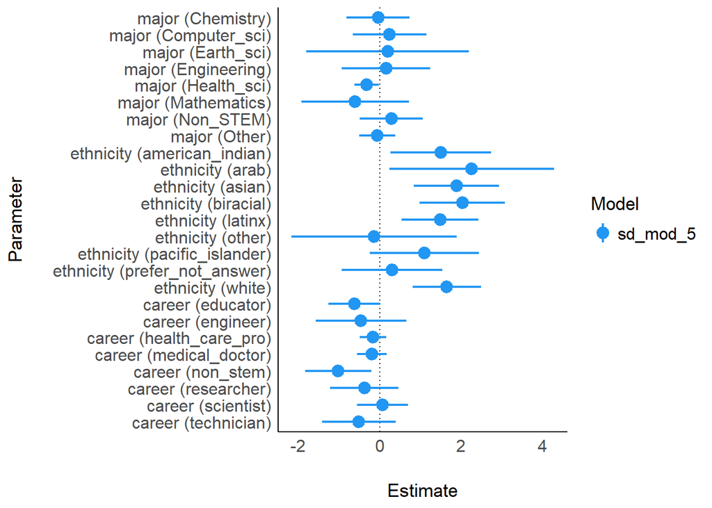

Well awesome, this gives us a great place that we can start in further data analysis in our project.

[figure not shown]

### [**NEXT**](https://pbischoff3.github.io/Projects/BIOL_3100/models/se/)